# PA1_template

F Alma S

Thursday, October 27, 2016

```r
#*******************************************************#
# Author: F Almah S                                     #
# Module 5 | PA Course Project 1                        #
# Date: 24.10.16                                        #
#*******************************************************#

# set working directory
setwd("C:/Users/tm35082/Desktop/New files/Cousera/Module5/Week2")

#set the library
library(ggplot2)
library(knitr)

# unzip and load data from local directory
unzip(zipfile="activity.zip")
data <- read.csv("activity.csv")

#data checking
head(data)
```

```
##   steps       date interval
## 1    NA 2012-10-01        0
## 2    NA 2012-10-01        5
## 3    NA 2012-10-01       10
## 4    NA 2012-10-01       15
## 5    NA 2012-10-01       20
## 6    NA 2012-10-01       25
```

```r
#-------------------------------------------------------------------
```

# Q1: What is mean total number of steps taken per day?

## 1. Calculate the total number of steps taken per day

## 2. If you do not understand the difference between a histogram

## and a barplot, research the difference between them.

## Make a histogram of the total number of steps taken each day

## 3. Calculate and report the mean and median of the total number of steps taken per day

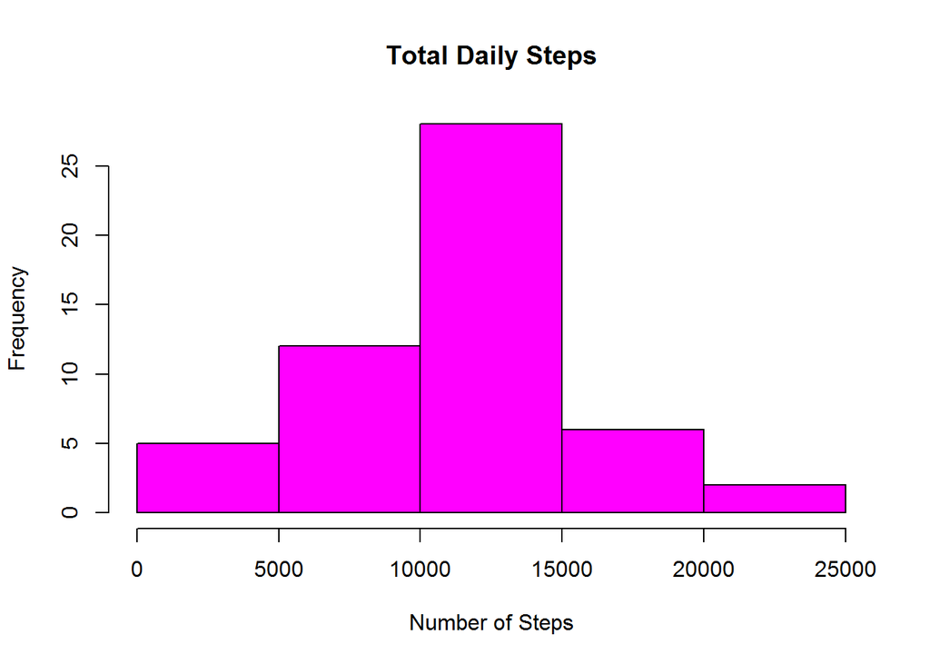

```r
day.steps <- aggregate(steps ~ date, data, sum)

#prepare the .png file first
#png("stepsdaily.png", width=480, height=480)

hist(day.steps$steps, main = paste("Total Daily Steps"), col="magenta", xlab="Number of Steps")
```

```r
mean(day.steps$steps, na.rm=TRUE)
```

```
## [1] 10766.19
```

```r
median(day.steps$steps, na.rm=TRUE)
```

```
## [1] 10765
```

```
#> mean(day.steps$steps, na.rm=TRUE)
```

```r
#[1] 10766.19
```

```
#> median(day.steps$steps, na.rm=TRUE)
```

```r
#[1] 10765

#-------------------------------------------------------------------
```

# Q2: What is the average daily activity pattern?

## 1. Make a time series plot (i.e. type = “l”) of the 5-minute interval (x-axis)

## and the average number of steps taken, averaged across all days (y-axis)

## 2. Which 5-minute interval, on average across all the days in the dataset,

## contains the maximum number of steps?

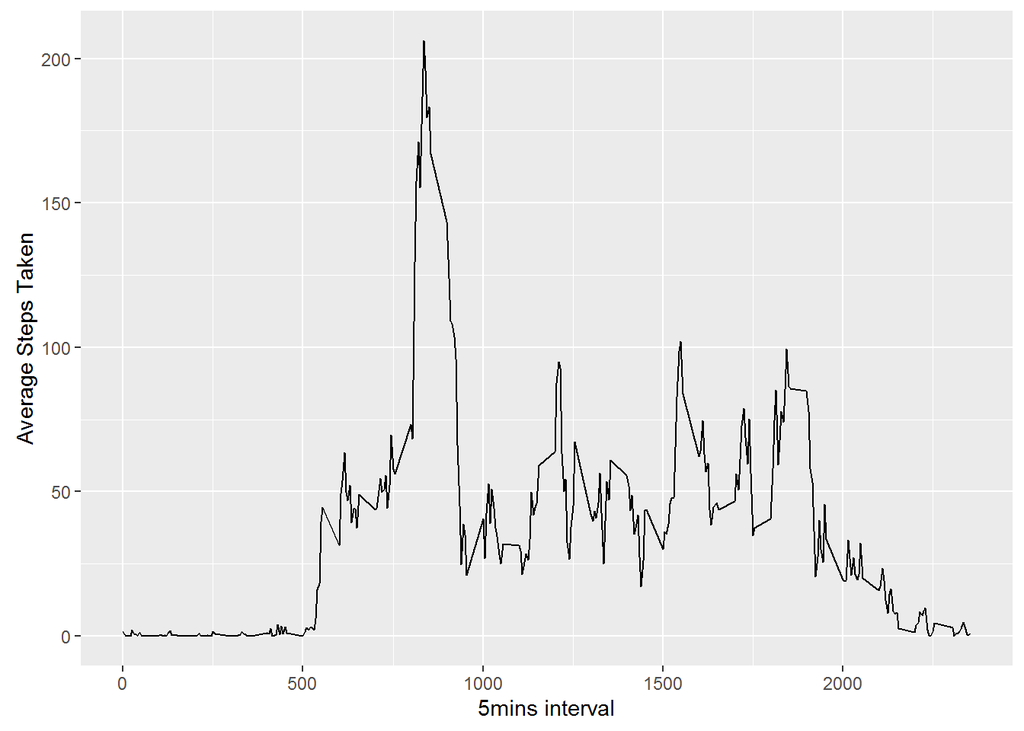

```r
avg.steps <- aggregate(x=list(steps=data$steps), by=list(interval=data$interval),
             FUN=mean, na.rm=TRUE)

#prepare the .png file first
#png("avg5mins.png", width=480, height=480)

ggplot(data=avg.steps, aes(x=interval, y=steps)) +
  geom_line() +
  xlab("5mins interval") +
  ylab("Average Steps Taken")
```

```r
avg.steps[which.max(avg.steps$steps),]
```

```
##     interval    steps
## 104      835 206.1698
```

```
#> avg.steps[which.max(avg.steps$steps),]
```

```r
#interval    steps
#104      835 206.1698

#-------------------------------------------------------------------
```

# Q3. Imputing step.missing values

## Note that there are a number of days/intervals where there are

## step.missing values (coded as NA). The presence of step.missing days may introduce

## bias into some calculations or summaries of the data.

## 1. Calculate and report the total number of step.missing values in the dataset

## (i.e. the total number of rows with NAs)

## 2. Devise a strategy for filling in all of the step.missing values in the dataset.

## The strategy does not need to be sophisticated. For example, you could use the

## mean/median for that day, or the mean for that 5-minute interval, etc.

## 3. Create a new dataset that is equal to the original dataset but with the step.missing data filled in.

## 4. Make a histogram of the total number of steps taken each day and Calculate

## and report the mean and median total number of steps taken per day. Do these values

## differ from the estimates from the first part of the assignment? What is the impact